# Explore and Summarize Data by KUNAL MANIK

# Talk about some of the relationships you observed in this part of the investigation. Were there features that strengthened each other in terms of looking at your feature(s) of interest?

Lower borrowing Rates are usually related to High Credit Score, High Prosper Score, High Prosper Rating and the fact that Borrower owns a Home. Borrowers with Lower Prosper Rating usually borrow less amount but on a high rate. Most of the borrowers have credit scores near 700. Higher Income Range and Higher Prosper Rating leads to Low Borrowing Rate.

# Were there any interesting or surprising interactions between features?

Most of the results were as expected.

### OPTIONAL: Did you create any models with your dataset? Discuss the strengths and limitations of your model.

# Plot One

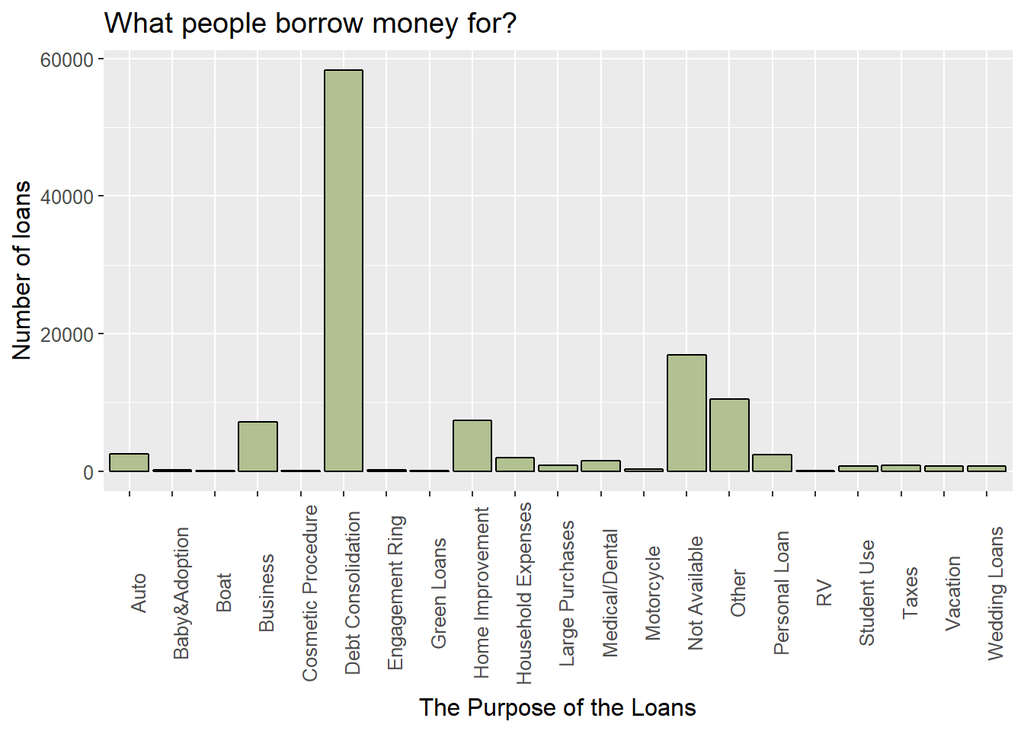

### Description One

In this plot we can see that the major part of the loans are classified under debt consolidation. 58308 loans (~51%) are under debt consolidation category.

A few factors contribute to the above statement.

1. Consolidating other high interest loans into one Prosper debt consolidation loan with a higher rate leads to saving of amount of interest that is charged on other debts every month.
2. Prosper debt consolidation loans are quite popular. The reason might be that they have a fixed interest rate.
3. Borrowers do not need to own a home for debt consolidation according to Proper’s policy of sanctioning loans.

### Plot Two

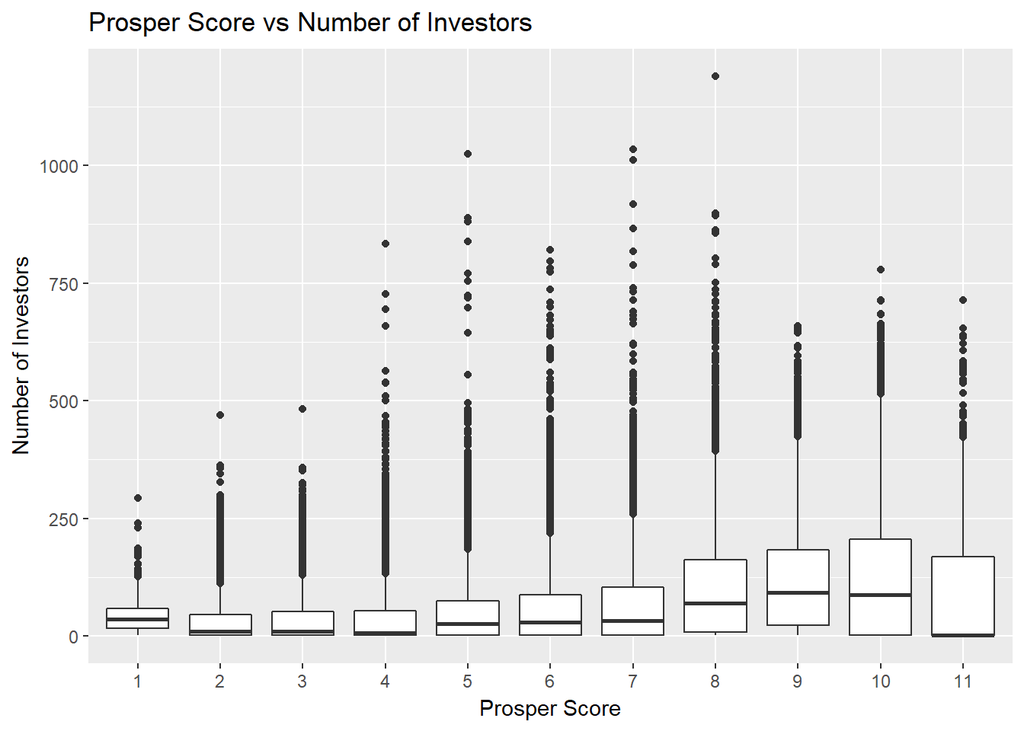

### Description Two

The maximum difference between number of investors falling between the First and the Third quartile is for the score of 10 where we have value of 1 for the First quartile and value of 206 for Third quartile.

The plots have been made as a subset of all loans created after July 1st, 2009 (loansAfter_01_07_09).

### Plot Three

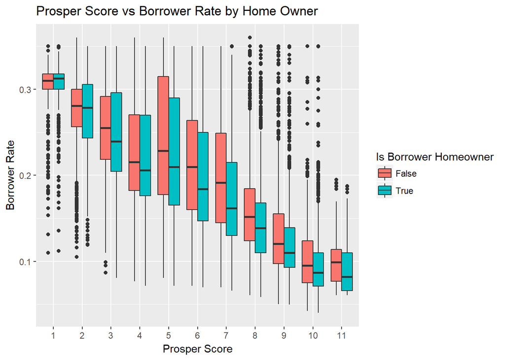

### Description Three

The plots have been made as a subset of all loans created after July 1st, 2009 (loansAfter_01_07_09).

# Reflection

This project gave me an in-depth knowledge about Prosper and its working as a Business. Exploring 113937 observations with more than 80 variables for each of them helped me realize how great the term, “ANALYSIS” is. I spent a lot of time on their website and went through the variables in their dataset as well. This process was quite tiresome initially but became interesting near the end.

Much of the difficulties came in the form - “Now, what to do next?”. Being completely unaware about the 2008-09 Economic Crisis, I wasn’t able to analyze the drop properly. It wasn’t until I researched, I was able to finally come to the point of conclusion.

Making comparisons between Proper Scores and several other variables made me realize how immportant the Proper Scores are in determining the relations between Borrowers and the actual Loans. That is why excluding the results before July 1st, 2009 was a better idea. Although, this in itself seems quite amusing how the analysis would have been carried for the values before the stated date.

For the future (including short-term and long-term goals), I am planing to analyze variables and the parameters that I didn’t cover or maybe, missed out in this particular analysis. I’ll sure learn more about this dataset than I already know so far. It would be better if I can get the latest dataset of Prosper. Since their last update was in 2014. 4 more years worth of data can easily help me to achieve the above and also help me to perform better Analysis. The main aim of this project was Exploratory Analysis. I plan to further my knowledge in this particular topic and go ahead with Predictive Models as well i.e. Predicting a pattern based on existing Relationships in Prosper data.

After getting all these analysis seems a bit easier than before. This also made me realize that there’s a lot more learn and practice.

# References

1. https://earthdatascience.org/courses/earth-analytics/document-your-science/knit-rmarkdown-document-to-pdf/
2. http://tutorials.iq.harvard.edu/R/Rgraphics/Rgraphics.html
3. Udacity Video Lectures and links provided as reference
4. http://ggplot2.tidyverse.org/reference/scale_hue.html